# Exercise 11

Author

Sarah Lötscher

Published

December 2, 2022

## STA426 Exercise 11

```r
set.seed(42)
```

```r
#Packages
library("ExperimentHub")
library("CATALYST")
library("diffcyt")
```

## Q1. Loading the data

```r
eh <- ExperimentHub()
```

```
snapshotDate(): 2022-10-31
```

```r
query(eh, "Bodenmiller")
```

```
ExperimentHub with 21 records
# snapshotDate(): 2022-10-31
# $dataprovider: NA, Bodenmiller Group
# $species: Homo sapiens
# $rdataclass: flowSet, SummarizedExperiment, data.frame
# additional mcols(): taxonomyid, genome, description,
#   coordinate_1_based, maintainer, rdatadateadded, preparerclass, tags,
#   rdatapath, sourceurl, sourcetype
# retrieve records with, e.g., 'object[["EH2254"]]'

           title
  EH2254 | Bodenmiller_BCR_XL_SE
  EH2255 | Bodenmiller_BCR_XL_flowSet
  EH3047 | Weber_BCR_XL_sim_main_SE
  EH3048 | Weber_BCR_XL_sim_main_flowSet
  EH3049 | Weber_BCR_XL_sim_null_rep1_SE
  ...      ...
  EH3061 | Weber_BCR_XL_sim_less_distinct_less_50pc_SE
  EH3062 | Weber_BCR_XL_sim_less_distinct_less_50pc_flowSet
  EH3063 | Weber_BCR_XL_sim_less_distinct_less_75pc_SE
  EH3064 | Weber_BCR_XL_sim_less_distinct_less_75pc_flowSet
  EH3564 | Damond Diabetes Spatial Dataset
```

```r
#Get "Bodenmiller_BCR_XL_flowSet"
dd<-eh[["EH2255"]]
```

```
snapshotDate(): 2022-10-31
```

```
see ?HDCytoData and browseVignettes('HDCytoData') for documentation
```

```
loading from cache
```

```r
dd
```

```
A flowSet with 16 experiments.

column names(39): Time Cell_length ... sample_id population_id
```

```r
#How many markers are recorded? How many samples are there? How many cells per sample?
for (x in 1:16) {
  print(dim(exprs(dd[[x]])))
}
```

```
[1] 2838   39
[1] 2739   39
[1] 16675    39
[1] 16725    39
[1] 12252    39
[1] 9434   39
[1] 8990   39
[1] 6906   39
[1] 8543   39
[1] 11962    39
[1] 8622   39
[1] 11038    39
[1] 14770    39
[1] 15974    39
[1] 11653    39
[1] 13670    39
```

## Q2. Constructing a SingleCellExperiment

```r
# download panel & metadata
url <- "http://imlspenticton.uzh.ch/robinson_lab/cytofWorkflow"
fns <- list(panel = "PBMC8_panel_v3.xlsx", md = "PBMC8_metadata.xlsx")
for (fn in fns) download.file(file.path(url, fn), destfile = fn, mode = "wb")

# load into R
library(readxl)
panel <- read_excel(fns$panel)
md <- read_excel(fns$md)
```

```r
#Construct a SCE

SCE <- prepData(dd, panel, md)
```

How many markers and how many cells are there?

```r
head(panel)
```

```
# A tibble: 6 × 3
  fcs_colname    antigen marker_class
  <chr>          <chr>   <chr>
1 CD3(110:114)Dd CD3     type
2 CD45(In115)Dd  CD45    type
3 pNFkB(Nd142)Dd pNFkB   state
4 pp38(Nd144)Dd  pp38    state
5 CD4(Nd145)Dd   CD4     type
6 CD20(Sm147)Dd  CD20    type
```

```r
head(md)
```

```
# A tibble: 6 × 4
  file_name                          sample_id condition patient_id
  <chr>                              <chr>     <chr>     <chr>
1 PBMC8_30min_patient1_BCR-XL.fcs    BCRXL1    BCRXL     Patient1
2 PBMC8_30min_patient1_Reference.fcs Ref1      Ref       Patient1
3 PBMC8_30min_patient2_BCR-XL.fcs    BCRXL2    BCRXL     Patient2
4 PBMC8_30min_patient2_Reference.fcs Ref2      Ref       Patient2
5 PBMC8_30min_patient3_BCR-XL.fcs    BCRXL3    BCRXL     Patient3
6 PBMC8_30min_patient3_Reference.fcs Ref3      Ref       Patient3
```

```r
dim(SCE)
```

```
[1]     24 172791
```

The panel table has three columns:

- fcs_colnames is name of marker
- antigen is protein identified by marker
- marker_class is a factor (with two levels) telling whether marker identified is indicative of cell type or cell state

The metadata table has four columns:

- file_name is the filename of experiment
- sample_id is unique id number for each experiment
- condition is a factor (with two levels) telling whether sample is treated or not
- patient_id is a factor (with eight levels) telling which patient sample was taken from

--> The SingleCellExperiment object has 24 markers and 172791 cells.

# Q3. Type and state markers

```r
#Print the set of type markers pre-defined in the SCE
type_markers(SCE)
```

```
 [1] "CD3"    "CD45"   "CD4"    "CD20"   "CD33"   "CD123"  "CD14"   "IgM"
 [9] "HLA-DR" "CD7"
```

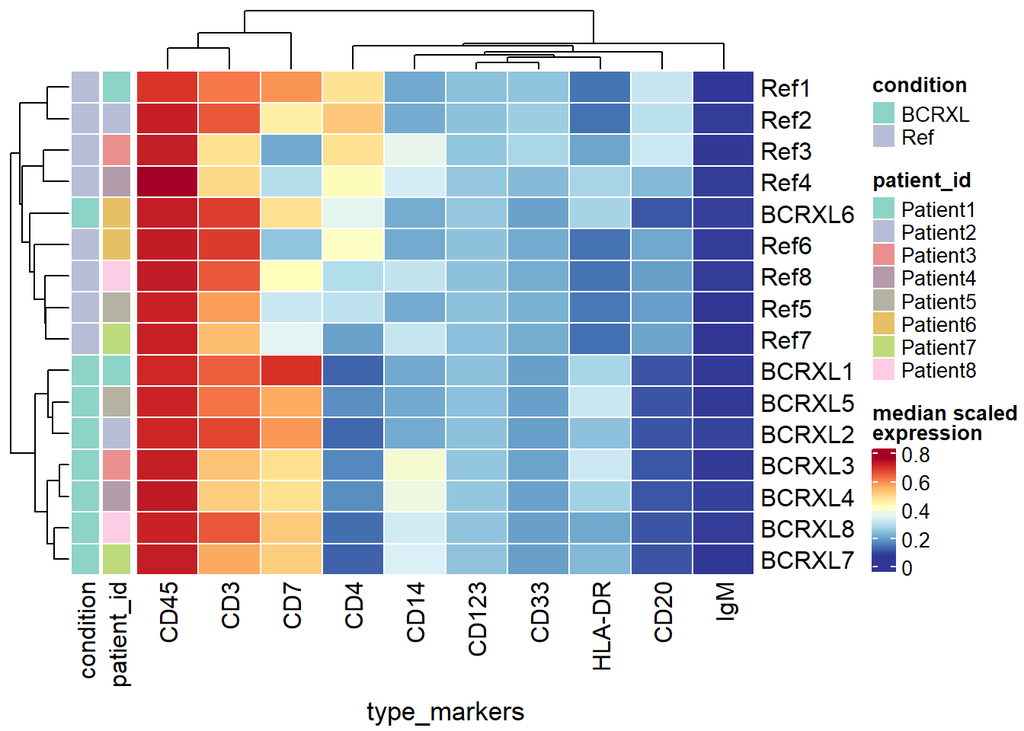

```r
#Plot a heatmap of median marker expression across samples
plotExprHeatmap(SCE, features = "type", by = "sample_id")
```

Are there type markers that may violate the above assumption?

There are some markers that may speak against consistent marker expressions across experimental groups. For example see the markers: CD20,CD4 and CD7.

# Q4. Clustering

```r
# Cluster the data into 8x8 high-resolution-, and 2-10 metaclusters.

SCE_C <- cluster(SCE, features = "type",xdim = 8, ydim = 8, maxK = 10,seed = 1)
```

```
o running FlowSOM clustering...
```

```
o running ConsensusClusterPlus metaclustering...
```

```r
colData(SCE_C)
```

```
DataFrame with 172791 rows and 4 columns
       sample_id condition patient_id cluster_id
        <factor>  <factor>   <factor>   <factor>
1         BCRXL1     BCRXL   Patient1         9
2         BCRXL1     BCRXL   Patient1         9
3         BCRXL1     BCRXL   Patient1         49
4         BCRXL1     BCRXL   Patient1         14
5         BCRXL1     BCRXL   Patient1         33
...          ...       ...        ...        ...
172787      Ref8       Ref   Patient8         37
172788      Ref8       Ref   Patient8         5
172789      Ref8       Ref   Patient8         2
172790      Ref8       Ref   Patient8         3
172791      Ref8       Ref   Patient8         35
```

```r
#Calculate (and print a table of) the percentage of cells assigned to each cluster at the 8-metacluster level of clustering (meta8), for each sample (or condition).


table(cluster_ids(SCE_C, "meta8"))/sum(table(cluster_ids(SCE_C, "meta8")))*100
```

```
        1         2         3         4         5         6         7         8
35.463074  3.312673  9.863940 14.832948 12.813746 16.102691  5.339398  2.271530
```

```r
table(cluster_ids(SCE_C, "meta8")[colData(SCE_C)$condition == "BCRXL"])/sum(table(cluster_ids(SCE_C, "meta8")[colData(SCE_C)$condition == "BCRXL"]))*100
```

```
        1         2         3         4         5         6         7         8
33.170506  4.088069  8.592296 16.841943 10.056555 20.557723  4.425975  2.266934
```

```r
table(cluster_ids(SCE_C, "meta8")[colData(SCE_C)$condition == "Ref"])/sum(table(cluster_ids(SCE_C, "meta8")[colData(SCE_C)$condition == "Ref"]))*100
```

```
        1         2         3         4         5         6         7         8
37.649240  2.573263 11.076565 12.917194 15.442972 11.854423  6.210429  2.275914
```

Using the percentages, given an example of clusters that are equally, more or less frequent in one condition than the other:

-As an example of clusters that is equally in one condition than the other is for example cluster nr 8 which the percenatge is around 2.3%.

# Q5. Dimension reduction

```r
#Using runDR(), compute a UMAP embedding of at most 500 cells per sample.

SCE_R <- runDR(SCE_C, dr = "UMAP", cells = 500, features = "type")
```

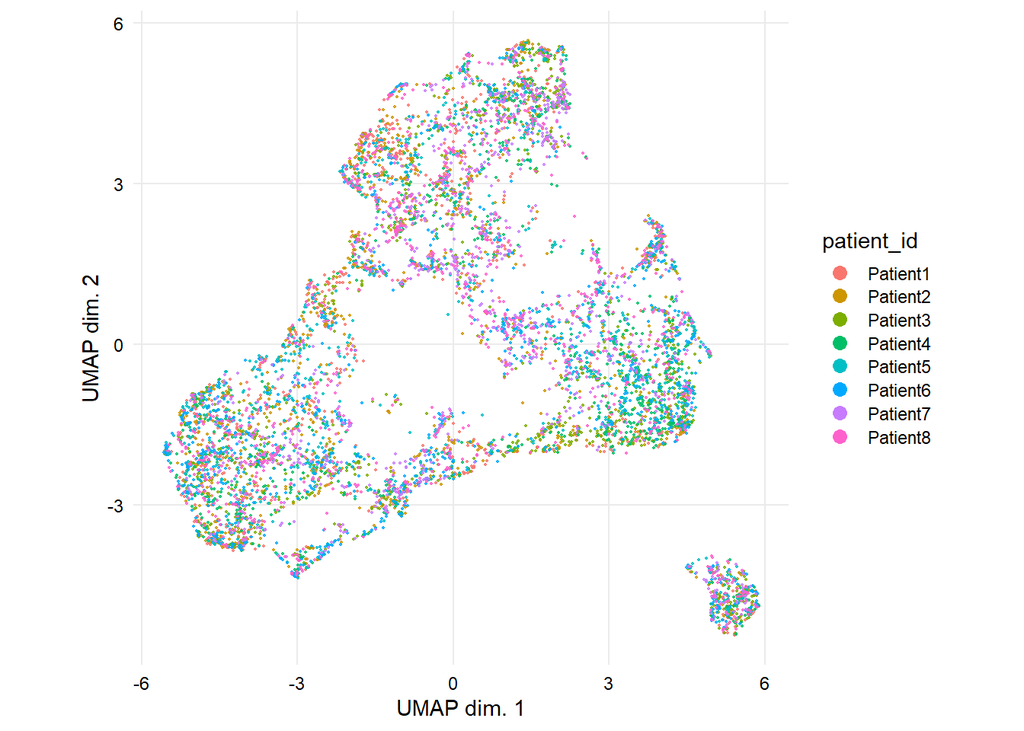

```r
#Using plotDR(), plot UMAP embeddings colored by patient_id and condition.

plotDR(SCE_R, color_by = "patient_id")
```

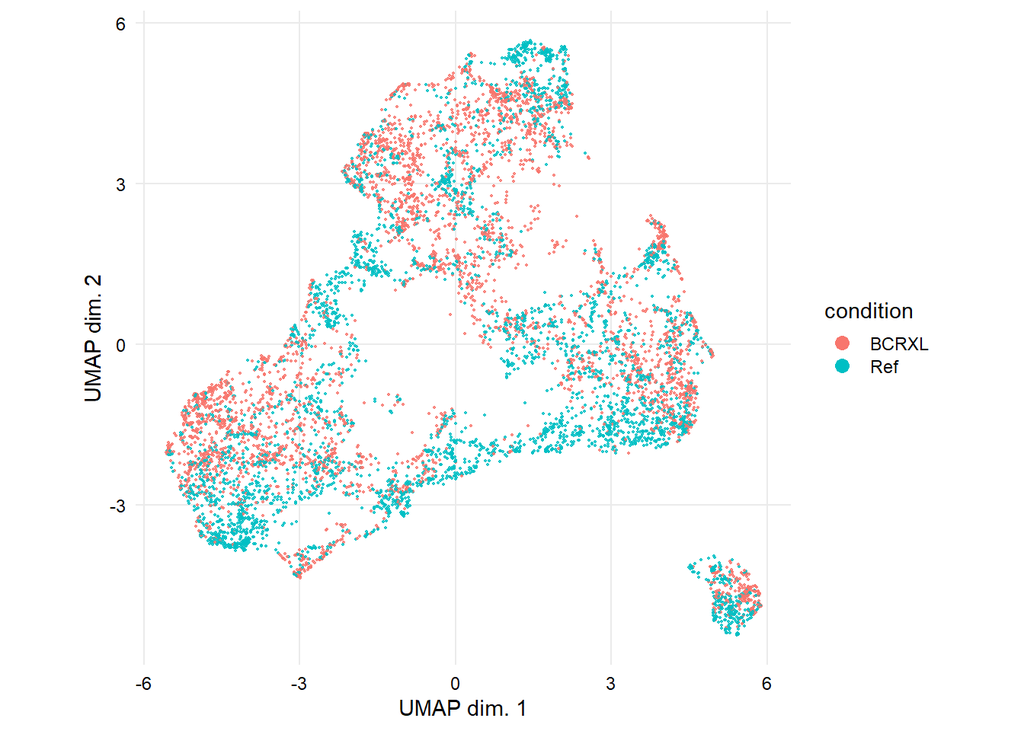

```r
plotDR(SCE_R, color_by = "condition")
```

Is there any apparent patient effect?

From the plot colored by patient_id we can see that the distribution of the patients is quite homogeneous this suggests against any apparent patient/batch effect.

How does BCRXL stimulation manifest itself?

From the plot colored by condition we can see that the BCRXL stimulation shifts the points in certain regions, making them group together more. This suggests that there is difference between the conditions.

# Q6. Exploratory data analysis

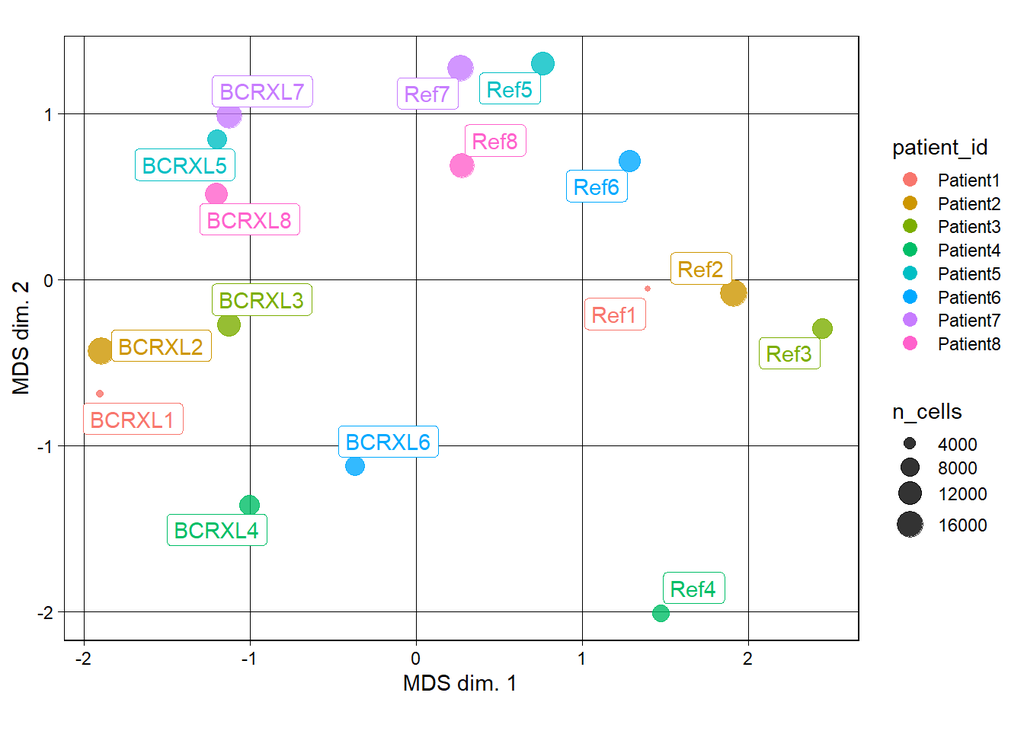

```r
#Generate MDS plots with samples colored by patient_id and condition.

pbMDS(SCE_R, color_by = "patient_id")
```

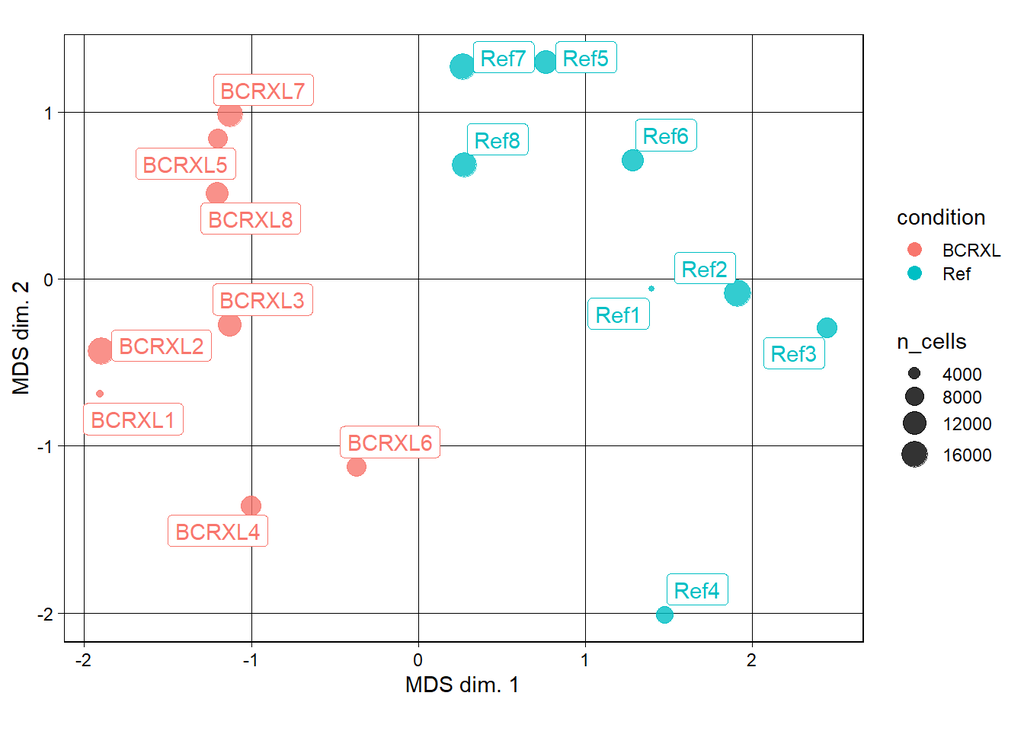

```r
pbMDS(SCE_R, color_by = "condition")
```

Comment on how samples group together or are separated from one another:

From the plots we can see that the dissimilarity between the condtions is bigger than the dissimilarity between patients. In the plot colored by patient_id we can see that there are patient individual differences/variiation between the samples. In the plot colored by conditions we can see that there is a nice and clear split between the two conditions along the MDS dimmension 1.

# Q7. Differential state (DS) analysis

```r
# extract experimental design table
ei <- metadata(SCE_R)$experiment_info

# create model formulas with & without patient effect
ds_formula1 <- createFormula(ei, cols_fixed = "condition", cols_random = "patient_id")
ds_formula2 <- createFormula(ei, cols_fixed = "condition")

# create contrast matrix
#contrast1 <- createContrast(c(0, 1, rep(0, 7)))
contrast <- createContrast(c(0, 1))



# run 'diffcyt' 2x
res_ds1 <- diffcyt(SCE_R, ei,
    formula = ds_formula1,
    contrast = contrast,
    analysis_type = "DS",
    method_DS = "diffcyt-DS-LMM",
    clustering_to_use = "meta8")
```

```
using SingleCellExperiment object from CATALYST as input
```

```
using cluster IDs from clustering stored in column 'meta8' of 'cluster_codes' data frame in 'metadata' of SingleCellExperiment object from CATALYST
```

```
calculating features...
```

```
calculating DS tests using method 'diffcyt-DS-LMM'...
```

```
boundary (singular) fit: see help('isSingular')
boundary (singular) fit: see help('isSingular')
boundary (singular) fit: see help('isSingular')
```

```
boundary (singular) fit: see help('isSingular')
boundary (singular) fit: see help('isSingular')
boundary (singular) fit: see help('isSingular')
```

```r
res_ds2 <- diffcyt(SCE_R, ei,
    formula = ds_formula2,
    contrast = contrast,
    analysis_type = "DS",
    method_DS = "diffcyt-DS-LMM",
    clustering_to_use = "meta8")
```

```
using SingleCellExperiment object from CATALYST as input
```

```
using cluster IDs from clustering stored in column 'meta8' of 'cluster_codes' data frame in 'metadata' of SingleCellExperiment object from CATALYST
```

```
calculating features...
```

```
calculating DS tests using method 'diffcyt-DS-LMM'...
```

```r
#Print a table of the number of DS findings for each model at an FDR cutoff of 5%.

#res_ds1
cutoff <- 0.05
res_ds1_all <- topTable(res_ds1, all = TRUE)
table(res_ds1_all$p_adj <= cutoff)
```

```
FALSE  TRUE
   28    84
```

```r
#res_ds2
cutoff <- 0.05
res_ds2_all <- topTable(res_ds2, all = TRUE)
table(res_ds2_all$p_adj <= cutoff)
```

```
FALSE  TRUE
   70    42
```

How many tests are there in total and why?

In total there were 112 tests. This is given by the number of clusters (which is 8) times the number of Markers (which is 14) because each marker is tested for each cluster.

Comment on what effect accounting for patient variability has on sensitivity.

Because there is a increased number in detentions when we take the patient_id into account in our model, this would suggests an increase in sensitivity.

# Q8. Visualizing DS results

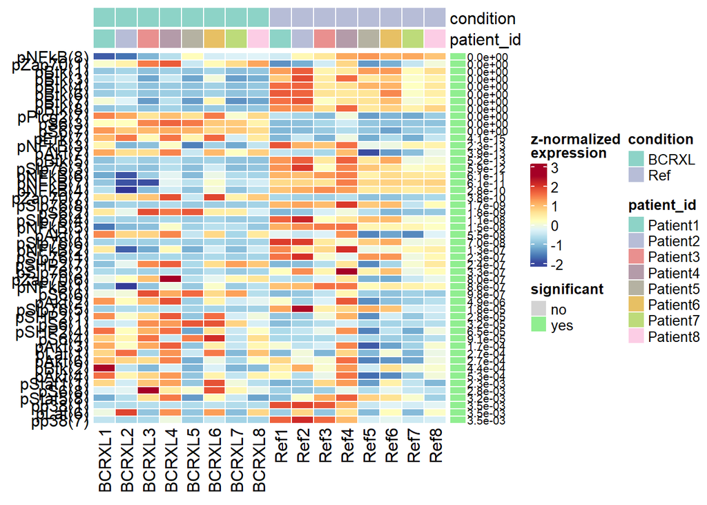

```r
#Visualize the top 50 hits using plotDiffHeatmap

plotDiffHeatmap(SCE_R, rowData(res_ds1$res), all = TRUE, fdr = cutoff, top_n = 50,sort_by = "padj")
```

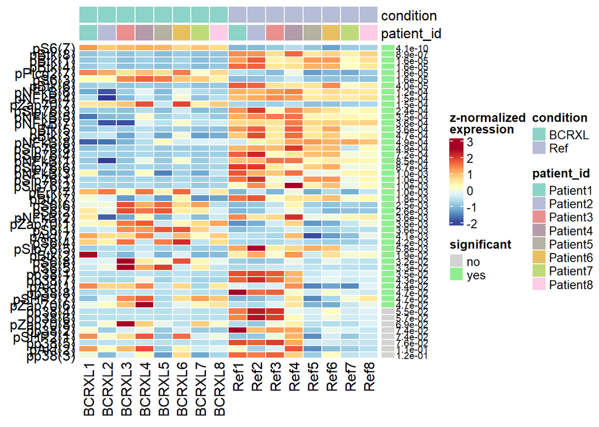

```r
plotDiffHeatmap(SCE_R, rowData(res_ds2$res), all = TRUE, fdr = cutoff, top_n = 50,sort_by = "padj")
```

[figure not shown]

```r
#Plot UMAPs colored by their expression and split by condition.

plotDR(SCE_R, color_by = rownames(SCE_R), facet_by = "condition")
```